[figure not shown]

# **Projeto II - Implementação de um Modelo de Decisão Bayesiano para a compra de um seguro de vida**

### **Mestrado em Engenharia e Ciência de Dados | 2024-2025**

### **Fusão de Informação em Análise de Dados**

Eduardo Soares das Neves Cardoso, nº 2021226956

Matilde Martins Reis, nº 2021237887

## **Introdução**

Este projeto tem como objetivo desenvolver um modelo de decisão Bayesiano aplicado à recomendação da aquisição de um seguro de vida, através da fusão de características relativas a diversos indivíduos.

```python
import numpy as np
import pandas as pd
import seaborn as sns
import matplotlib.pyplot as plt
import plotly.express as px
from sklearn.model_selection import train_test_split
from sklearn.metrics import confusion_matrix, ConfusionMatrixDisplay
from sklearn.metrics import classification_report, accuracy_score

from scipy.stats import kstest, shapiro, norm

from google.colab import drive
drive.mount('/content/drive')
```

```python
file_path = '/content/drive/MyDrive/lifeInsurance.txt'
```

## **Dataset**

O conjunto de dados a utilizar é constituido por oito variáveis que caracterizam o perfil de 600 indivíduos distintos. Inclui as seguintes informações:

- Gender: 0 = feminino, 1 = masculino;
- Age: valor entre 34 e 101;
- Marital_Status: 0 = solteiro, 1 = casado;
- N_children: 0 = sem dependentes, 1 = um dependente, 2 = dois dependentes, 3 = 3 ou mais dependentes;
- Physical_Status: 0 = sedentário, 1 = moderadamente ativo, 2 = ativo;
- Chronic_disease: 0 = sem condições de saúde graves, 1 = condição moderada, 2 = condição grave;
- Monthly_Salary: valor entre 1370€ e 3800€.
- Recommendation: sugestão de uma seguradora sobre se o indivíduo deve comprar (1) ou não (0) o seguro. É obtida com base num conjunto de regras que envolve as outras variáveis.

O *target*, Decision, é uma variável binária e indica se o indivíduo optou (classe 1) ou não (classe 0) pela aquisição do seguro de vida.

```python
df = pd.read_csv(file_path, sep='\s+', header=None)
df.head()
```

|  | 0 | 1 | 2 | 3 | 4 | 5 | 6 | 7 |
| --- | --- | --- | --- | --- | --- | --- | --- | --- |
| 0 | 0.0 | 80.0 | 1.0 | 1.0 | 1.0 | 0.0 | 2611.4159 | 0.0 |
| 1 | 0.0 | 101.0 | 1.0 | 3.0 | 1.0 | 1.0 | 3132.2018 | 1.0 |
| 2 | 0.0 | 34.0 | 1.0 | 3.0 | 1.0 | 1.0 | 2462.3115 | 1.0 |
| 3 | 0.0 | 34.0 | 0.0 | 1.0 | 1.0 | 1.0 | 3051.9166 | 0.0 |
| 4 | 0.0 | 93.0 | 1.0 | 2.0 | 1.0 | 1.0 | 2401.4440 | 1.0 |

```python
# Renomear as colunas
df.columns = ["Gender", "Age", "Marital_status", "N_children", "Physical_Status", "Chronic_disease", "Monthly_Salary", "Decision"]
df.head()
```

|  | Gender | Age | Marital_status | N_children | Physical_Status | Chronic_disease | Monthly_Salary | Decision |
| --- | --- | --- | --- | --- | --- | --- | --- | --- |
| 0 | 0.0 | 80.0 | 1.0 | 1.0 | 1.0 | 0.0 | 2611.4159 | 0.0 |
| 1 | 0.0 | 101.0 | 1.0 | 3.0 | 1.0 | 1.0 | 3132.2018 | 1.0 |
| 2 | 0.0 | 34.0 | 1.0 | 3.0 | 1.0 | 1.0 | 2462.3115 | 1.0 |
| 3 | 0.0 | 34.0 | 0.0 | 1.0 | 1.0 | 1.0 | 3051.9166 | 0.0 |
| 4 | 0.0 | 93.0 | 1.0 | 2.0 | 1.0 | 1.0 | 2401.4440 | 1.0 |

```python
df.shape
```

```
(600, 8)
```

#### Pré-Processamento

Nesta etapa verificamos tanto a existência de valores em falta como de linhas duplicadas.

```python
df.info()
```

```
<class 'pandas.core.frame.DataFrame'>
RangeIndex: 600 entries, 0 to 599
Data columns (total 8 columns):
 #   Column           Non-Null Count  Dtype
---  ------           --------------  -----
 0   Gender           600 non-null    float64
 1   Age              600 non-null    float64
 2   Marital_status   600 non-null    float64
 3   N_children       600 non-null    float64
 4   Physical_Status  600 non-null    float64
 5   Chronic_disease  600 non-null    float64
 6   Monthly_Salary   600 non-null    float64
 7   Decision         600 non-null    float64
dtypes: float64(8)
memory usage: 37.6 KB
```

```python
df.isnull().sum()
```

|  | 0 |
| --- | --- |
| Gender | 0 |
| Age | 0 |
| Marital_status | 0 |
| N_children | 0 |
| Physical_Status | 0 |
| Chronic_disease | 0 |
| Monthly_Salary | 0 |
| Decision | 0 |

**dtype:** int64

```python
duplicadas = df.duplicated()
print("Número de linhas duplicadas:", duplicadas.sum())
```

```
Número de linhas duplicadas: 0
```

Uma vez que não há valores nulos nem linhas duplicadas, não foi necessário realizar nenhum tipo de pré-processamento.

## **Sugestão da Seguradora**

Uma das variáveis a utilizar corresponde a uma sugestão da seguradora sobre se um indivíduo deve ou não comprar o seguro, com base num score calculado através das restantes variáveis. Assim, procedemos ao cálculo deste valor.

```python
# Calcular recomendação da seguradora com base em regras

def insurance_recommendation(row):
  score_point = 0

  # Age
  if row['Age'] < 30:
    score_point += 5
  elif 30 <= row['Age'] < 40:
    score_point += 10
  elif 40 <= row['Age'] <= 50:
    score_point += 15
  else:
    score_point += 20

  # Chronic diseases
  if row['Chronic_disease'] == 0:
    score_point += 5
  elif row['Chronic_disease'] == 1:
    score_point += 10
  else:
    score_point += 15

  # Monthly Salary
  if row['Monthly_Salary'] > 3500:
    score_point += 5
  elif 1700 <= row['Monthly_Salary'] <= 3500:
    score_point += 10
  else:
    score_point += 15

  # Number of children
  if row['N_children'] == 0:
    score_point += 5
  elif row['N_children'] == 1:
    score_point += 10
  else:
    score_point += 15

  # Recomendação da seguradora
  if score_point > 50:
    return 1
  else:
    return 0
```

```python
df['Recommendation'] = df.apply(insurance_recommendation, axis=1)

# Reordenar as colunas
df = df[df.columns.tolist()[:-2] + ['Recommendation', 'Decision']]

df.head()
```

|  | Gender | Age | Marital_status | N_children | Physical_Status | Chronic_disease | Monthly_Salary | Recommendation | Decision |
| --- | --- | --- | --- | --- | --- | --- | --- | --- | --- |
| 0 | 0.0 | 80.0 | 1.0 | 1.0 | 1.0 | 0.0 | 2611.4159 | 0 | 0.0 |
| 1 | 0.0 | 101.0 | 1.0 | 3.0 | 1.0 | 1.0 | 3132.2018 | 1 | 1.0 |
| 2 | 0.0 | 34.0 | 1.0 | 3.0 | 1.0 | 1.0 | 2462.3115 | 0 | 1.0 |
| 3 | 0.0 | 34.0 | 0.0 | 1.0 | 1.0 | 1.0 | 3051.9166 | 0 | 0.0 |
| 4 | 0.0 | 93.0 | 1.0 | 2.0 | 1.0 | 1.0 | 2401.4440 | 1 | 1.0 |

```python
accuracy = (df['Recommendation'] == df['Decision']).mean()
print(f"Accuracy: {accuracy:.2%}")
```

```
Accuracy: 76.00%
```

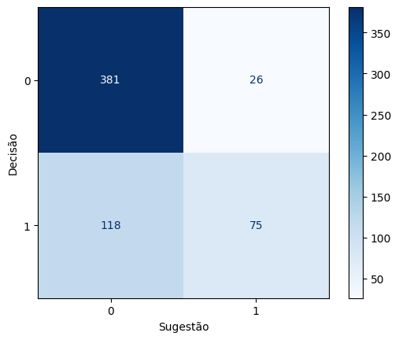

```python
cm = confusion_matrix(df['Decision'], df['Recommendation'])
disp = ConfusionMatrixDisplay(confusion_matrix=cm)
disp.plot(cmap='Blues')

plt.xlabel("Sugestão")
plt.ylabel("Decisão")
plt.show()
```

A sugestão da seguradora:

- apresenta um bom desempenho na identificação de indivíduos que não adquiriram o seguro, com 381 classificações corretas e apenas 26 falsos positivos.
- verifica um número considerável de falsos negativos (118), indicando uma tendência para não recomendar a aquisição. Ainda assim, a variável possui alguma capacidade em reconhecer perfis que efetivamente compraram o seguro, com 75 acertos.

Desta forma, concluímos que esta variável, de forma individual, não parece ter um desempenho eficaz na classificação final. Ainda assim, acreditamos que em conjunto com as restantes variáveis poderá levar a um bom resultado.

## **Análise Exploratória**

Como parte da análise exploratória, realizamos a análise da correlação entre as variáveis. Desta forma, é possível identificar possíveis dependências entre as **variáveis**, com foco especial naquelas que **podem influenciar diretamente a variável de decisão.**

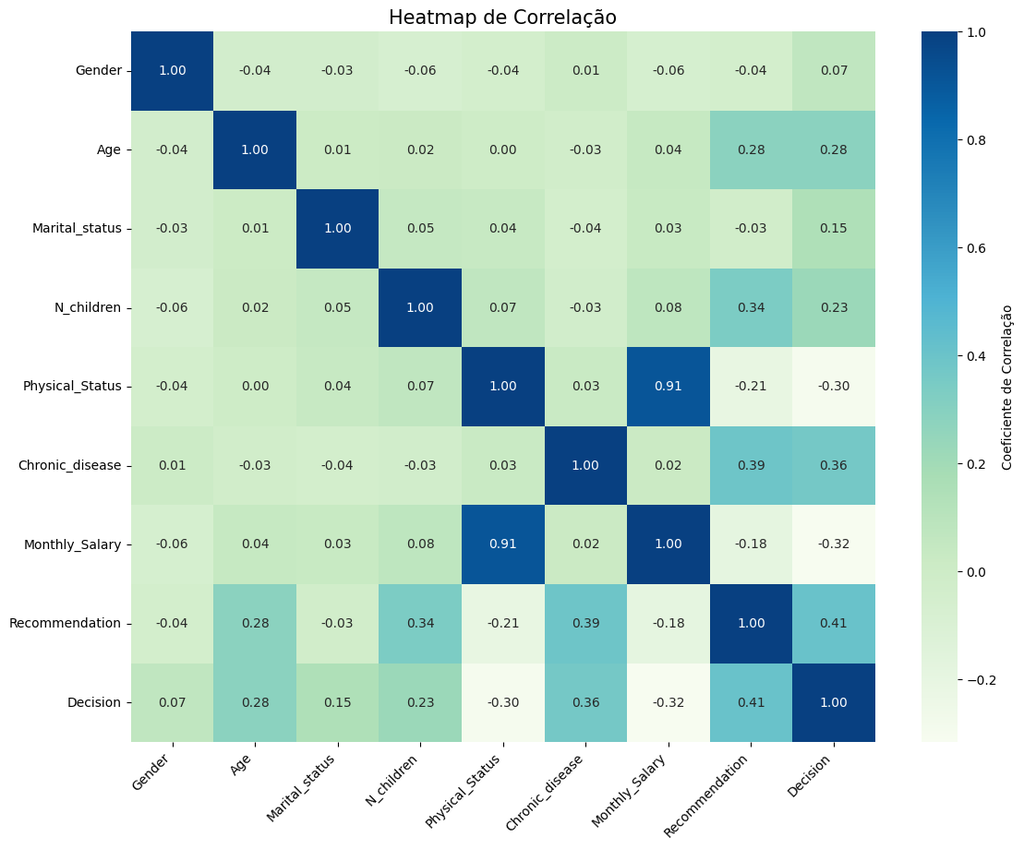

```python
corr_matriz = df.corr()

plt.figure(figsize=(13, 10))
sns.heatmap(corr_matriz, annot=True, fmt=".2f", cmap='GnBu', cbar_kws={'label': 'Coeficiente de Correlação'})
plt.xticks(rotation=45, fontsize=10, ha='right')
plt.yticks(rotation=0,fontsize=10)
plt.title('Heatmap de Correlação', fontsize=15)
plt.show()
```

Com base na análise de correlação, as **variáveis que mais influenciam a decisão são**:

- Recommendation, com correlação de 0.41;
- Chronic_disease, com 0.36;
- Monthly_Salary, com -0.32;
- Physical_Status, com -0.30;
- Age, com 0.28;
- N_children, com 0.23.

Por outro lado, as variáveis Gender e Marital_Status apresentam correlações mais baixas, de 0.07 e 0.15, respetivamente, o que indica que têm pouca ou nenhuma influência sobre a variável de decisão.

- **Variável "Number of children"**

```python
n_children = df['N_children'].value_counts()
n_children
```

| N_children | count |
| --- | --- |
| 1.0 | 152 |
| 3.0 | 152 |
| 0.0 | 151 |
| 2.0 | 145 |

**dtype:** int64

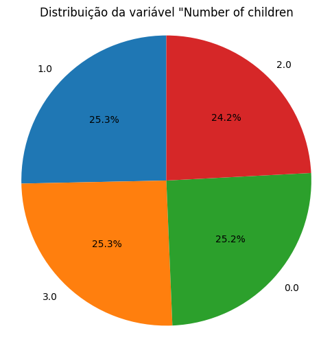

```python
plt.figure(figsize=(6,6))
plt.pie(n_children, labels=n_children.index, autopct='%1.1f%%', startangle=90)
plt.title('Distribuição da variável "Number of children')
plt.axis('equal')
plt.show()
```

- **Variável "Age"**

```python
n_age = df['Age'].value_counts()
n_age
```

| Age | count |
| --- | --- |
| 34.0 | 101 |
| 43.0 | 15 |
| 63.0 | 14 |
| 45.0 | 14 |
| 56.0 | 13 |
| ... | ... |
| 101.0 | 4 |
| 77.0 | 4 |
| 57.0 | 4 |
| 69.0 | 4 |
| 50.0 | 3 |

61 rows × 1 columns

**dtype:** int64

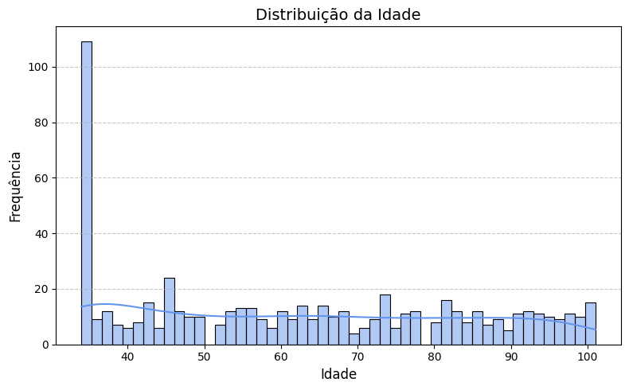

```python
plt.figure(figsize=(8, 5))
sns.histplot(df['Age'], bins=50, kde=True, color='cornflowerblue')
plt.title('Distribuição da Idade', fontsize=14)
plt.xlabel('Idade', fontsize=12)
plt.ylabel('Frequência', fontsize=12)
plt.grid(axis='y', linestyle='--', alpha=0.7)
plt.tight_layout()
plt.show()
```

- **Variável "Chronic Disease"**

```python
print(df['Chronic_disease'].value_counts())
```

```
Chronic_disease
0.0    294
1.0    266
2.0     40
Name: count, dtype: int64
```

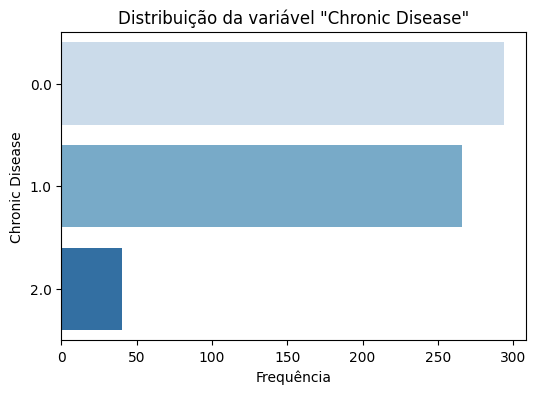

```python
chronic = df['Chronic_disease'].value_counts()

plt.figure(figsize=(6, 4))
sns.barplot(y=chronic.index.astype(str), x=chronic.values, palette='Blues', hue=chronic.index.astype(str), legend=False)
plt.title('Distribuição da variável "Chronic Disease"')
plt.xlabel('Frequência')
plt.ylabel('Chronic Disease')
plt.show()
```

- **Variável "Physical Status"**

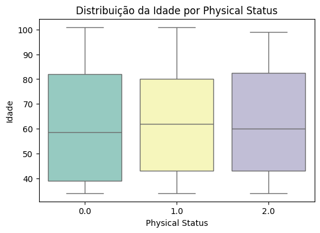

```python
plt.figure(figsize=(6, 4))
sns.boxplot(x='Physical_Status', y='Age', data=df, palette='Set3', hue='Physical_Status', legend=False)
plt.title('Distribuição da Idade por Physical Status')
plt.xlabel('Physical Status')
plt.ylabel('Idade')
plt.show()
```

- **Variável "Monthly Salary"**

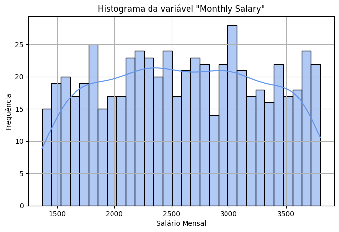

```python
plt.figure(figsize=(8, 5))
sns.histplot(df['Monthly_Salary'], bins=30, kde=True, color='cornflowerblue')
plt.title('Histograma da variável "Monthly Salary"')
plt.xlabel('Salário Mensal')
plt.ylabel('Frequência')
plt.grid(True)
plt.show()
```

A seguir realizámos a divisão dos dados em conjunto de treino e teste, com 80% dos dados a serem utilizados para treinar o modelo bayesiano. Utilizámos o parâmetro *stratify* para garantir que a proporção de classes nos dados de treino fosse o mais próxima possível da distribuição original.

```python
X_train, X_test, y_train, y_test = train_test_split(df.drop(['Decision'], axis=1), df['Decision'], test_size=0.2, random_state=42, stratify=df['Decision'])
print(f"Nº de dados de treino: {X_train.shape}")
print(f"Nº de dados de teste: {X_test.shape}")

print("\nProporção de classes nos dados de treino:")
print(y_train.value_counts(normalize=True))

print("\nProporção de classes nos dados de teste:")
print(y_test.value_counts(normalize=True))
```

```
Nº de dados de treino: (480, 8)
Nº de dados de teste: (120, 8)

Proporção de classes nos dados de treino:
Decision
0.0    0.679167
1.0    0.320833
Name: proportion, dtype: float64

Proporção de classes nos dados de teste:
Decision
0.0    0.675
1.0    0.325
Name: proportion, dtype: float64
```

## **Análise das variáveis contínuas**

As variáveis *Age* e *Monthly Salary* são variáveis contínuas, sendo necessário verificar se seguem uma distribuição normal. Para tal, utilizámos os testes de Kolmogorov-Smirnov e Shapiro-Wilk, com nível de significância de 0.05.

```python
def normalidade(variavel, nome):
    print(f"\n Variável contínua: {nome}")

    media = variavel.mean()
    desvio = variavel.std()

    # Visualizar histograma
    plt.figure(figsize=(8, 5))
    plt.hist(variavel, bins=30, density=True, alpha=0.6, color='green', label='Histograma')

    # Visualizar gráfico da distribuição normal
    x = np.linspace(variavel.min(), variavel.max(), 100)
    y = norm.pdf(x, media, desvio)
    plt.plot(x, y, color='blue', linewidth=2, label='Curva de Distribuição Normal')

    plt.title(f'Distribuição da variável {nome}')
    plt.xlabel(nome)
    plt.ylabel('Densidade')
    plt.legend()
    plt.grid(True)
    plt.show()

    # Teste de Kolmogorov–Smirnov
    ks_stat, ks_p = kstest(variavel, 'norm', args=(media, desvio))
    print(f"- Kolmogorov–Smirnov p-value: {ks_p:.4f}")

    # Teste de Shapiro–Wilk
    sw_stat, sw_p = shapiro(variavel)
    print(f"- Shapiro–Wilk p-value: {sw_p:.4f}")

    if ks_p < 0.05 or sw_p < 0.05:
        print("A variável não segue uma distribuição normal.")
    else:
        print("A variável segue uma distribuição normal.")
```

```
 Variável contínua: Age
```

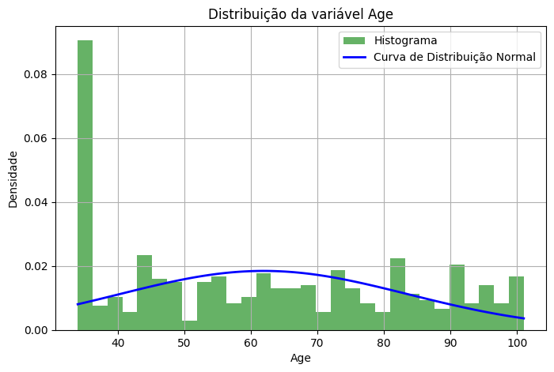

```
- Kolmogorov–Smirnov p-value: 0.0001
- Shapiro–Wilk p-value: 0.0000
A variável não segue uma distribuição normal.

 Variável contínua: Monthly_Salary
```

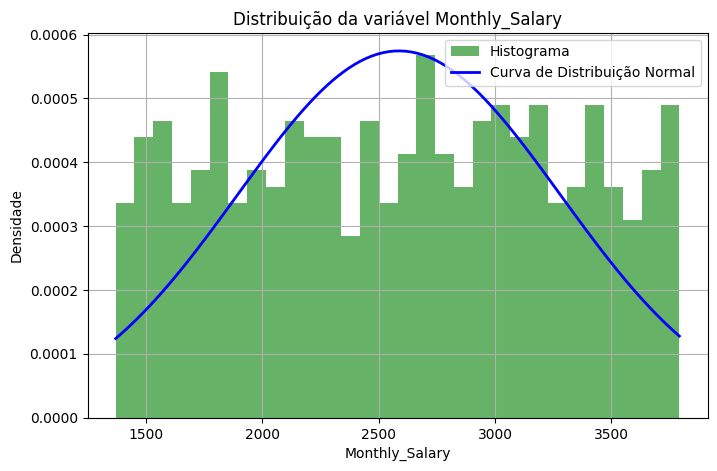

```
- Kolmogorov–Smirnov p-value: 0.0555
- Shapiro–Wilk p-value: 0.0000
A variável não segue uma distribuição normal.
```

```python
normalidade(X_train['Age'], 'Age')
normalidade(X_train['Monthly_Salary'], 'Monthly_Salary')
```

De acordo com ambos os testes realizados, a variável **Age** não segue uma distribuição normal.

A variável **Monthly Salary** segue uma distribuição normal de acordo com o teste de Kolmogorov-Smirnov. No entanto, uma vez que:

- o p-value é próximo de 0.05
- o teste de Shapiro-Wilk obteve um p-value de 0
- e o histograma de valores não parece sugerir uma distribuição normal

Concluímos que esta variável também não segue essa distribuição.

Assim, procedemos à discretização de ambas.

#### Discretização

##### variável **Age**

Optámos por dividir esta variável em 4 intervalos, os mesmos utilizados para calcular a sugestão da seguradora:

- categoria 0: 30 anos ou menos;
- categoria 1: entre 31 e 40;
- categoria 2: entre 41 e 50;
- categoria 3: mais de 50 anos.

```python
X_train_discret = X_train.copy()

# Discretizar a variável Age
bins = [0, 30, 40, 50, np.inf]
age_discret = pd.cut(X_train_discret['Age'], bins=bins, labels=[0, 1, 2, 3])

X_train_discret['Age'] = age_discret
X_train_discret.head()
```

|  | Gender | Age | Marital_status | N_children | Physical_Status | Chronic_disease | Monthly_Salary | Recommendation |
| --- | --- | --- | --- | --- | --- | --- | --- | --- |
| 115 | 0.0 | 1 | 1.0 | 2.0 | 0.0 | 0.0 | 2048.2215 | 0 |
| 336 | 0.0 | 3 | 1.0 | 3.0 | 2.0 | 1.0 | 3652.4079 | 0 |
| 282 | 1.0 | 3 | 0.0 | 2.0 | 1.0 | 0.0 | 2218.8748 | 0 |
| 40 | 0.0 | 3 | 0.0 | 2.0 | 1.0 | 1.0 | 3175.9454 | 1 |
| 39 | 0.0 | 3 | 0.0 | 0.0 | 1.0 | 0.0 | 3257.6204 | 0 |

##### variável **Monthly Salary**

Dividimos esta variável em 3 categorias, também utilizando os mesmos intervalos da sugestão da seguradora:

- categoria 0: até 1700€;
- categoria 1: entre 1700€ (exclusive) e 3500€;
- categoria 2: acima de 3500€;

```python
# Discretizar a variável Monthly Salaray
bins = [0, 1700, 3500, np.inf]
salary_discret = pd.cut(X_train_discret['Monthly_Salary'], bins=bins, labels=[0, 1, 2])

X_train_discret['Monthly_Salary'] = salary_discret
X_train_discret.head()
```

|  | Gender | Age | Marital_status | N_children | Physical_Status | Chronic_disease | Monthly_Salary | Recommendation |
| --- | --- | --- | --- | --- | --- | --- | --- | --- |
| 115 | 0.0 | 1 | 1.0 | 2.0 | 0.0 | 0.0 | 1 | 0 |
| 336 | 0.0 | 3 | 1.0 | 3.0 | 2.0 | 1.0 | 2 | 0 |
| 282 | 1.0 | 3 | 0.0 | 2.0 | 1.0 | 0.0 | 1 | 0 |
| 40 | 0.0 | 3 | 0.0 | 2.0 | 1.0 | 1.0 | 1 | 1 |
| 39 | 0.0 | 3 | 0.0 | 0.0 | 1.0 | 0.0 | 1 | 0 |

#### Alternativa: Gaussian Mixture Models

Em alternativa à discretização, resolvemos experimentar a utilização de GMMs para modelar ambas as variáveis, mantendo a sua natureza contínua.

```python
def gaussian_prob(x, u, var):
    return (1 / np.sqrt(2 * np.pi * var)) * np.exp(-(x - u)**2 / (2 * var))

# Implementar GMM
def gmm(variavel, w, u, var):

  for i in range(10):

    # Expectation step
    gamma_zi = []
    for valor in variavel:
        values = []
        for i in range(len(w)):
          v = (w[i] * gaussian_prob(valor, u[i], var[i])) / sum(w[i] * gaussian_prob(valor, u[i], var[i]) for i in range(len(w)))
          values.append(v)
        gamma_zi.append(values)

    gamma_zi = np.array(gamma_zi)

    # Maximization step
    for i in range(len(w)):

        # atualizar pesos
        w[i] = sum(gamma_zi[:,i]) / len(variavel)

        #atualizar médias
        u[i] = sum(gamma_zi[:,i] * variavel) / sum(gamma_zi[:,i])

        #atualizar variâncias
        var[i] = sum(gamma_zi[:,i] * (variavel - u[i])**2) / sum(gamma_zi[:,i])

  return np.round(w, 4), np.round(u, 4), np.round(var, 4)

def gmm_prob(x, w, u, var):
    return sum(w[i] * gaussian_prob(x, u[i], var[i]) for i in range(len(w)))
```

##### Variável **Age**

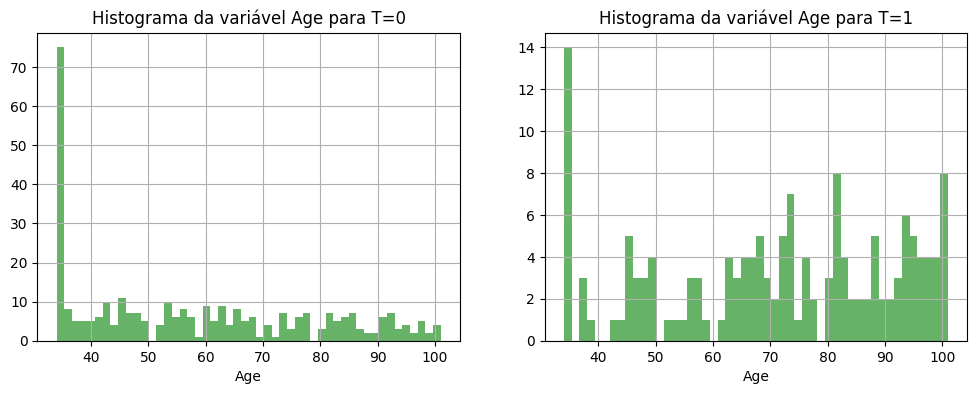

```python
age_t0 = X_train[y_train == 0]['Age']
age_t1 = X_train[y_train == 1]['Age']

fig, (ax1, ax2) = plt.subplots(1, 2, figsize=(12, 4))

# Histograma para a classe 0
ax1.hist(age_t0, bins=50, alpha=0.6, color='green', label='Histograma T=0')
ax1.set_title('Histograma da variável Age para T=0')
ax1.set_xlabel('Age')
ax1.grid()

# Histograma para a classe 1
ax2.hist(age_t1, bins=50, alpha=0.6, color='green', label='Histograma T=1')
ax2.set_title('Histograma da variável Age para T=1')
ax2.set_xlabel('Age')
ax2.grid()

plt.show()
```

Através da observação dos histogramas para cada classe, decidimos utilizar **3 clusters** para o modelo da classe 0 e **3 clusters** para o modelo da classe 1.

```python
# GMM para classe T=0

w = [0.7, 0.15, 0.15]
u = [35, 65, 90]
var = [10, 20, 20]

w_age_t0, u_age_t0, var_age_t0 = gmm(age_t0, w, u, var)
print(f"Age | Classe T=0: Pesos = {w_age_t0}")
print(f"Age | Classe T=0: Médias = {u_age_t0}")
print(f"Age | Classe T=0: Variâncias = {var_age_t0}\n")

# GMM para classe T=1

w = [0.4, 0.3, 0.3]
u = [40, 80, 100]
var = [10, 10, 10]

w_age_t1, u_age_t1, var_age_t1 = gmm(age_t1, w, u, var)
print(f"Age | Classe T=1: Pesos = {w_age_t1}")
print(f"Age | Classe T=1: Médias = {u_age_t1}")
print(f"Age | Classe T=1: Variâncias = {var_age_t1}")
```

```
Age | Classe T=0: Pesos = [0.316  0.4482 0.2357]
Age | Classe T=0: Médias = [35.5793 57.5484 87.3403]
Age | Classe T=0: Variâncias = [  7.6646 117.9939  58.8539]

Age | Classe T=1: Pesos = [0.2498 0.5349 0.2153]
Age | Classe T=1: Médias = [42.2775 74.3771 95.9636]
Age | Classe T=1: Variâncias = [ 59.2537 110.2451  11.269 ]
```

##### Variável **Monthly Salary**

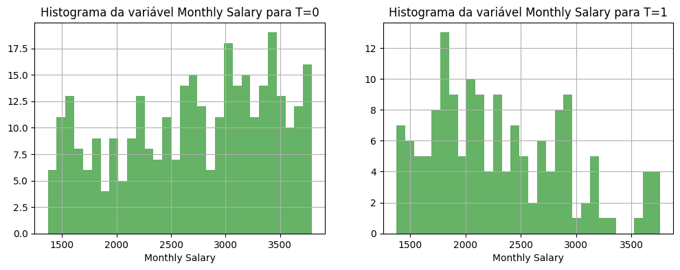

```python
salary_t0 = X_train[y_train == 0]['Monthly_Salary']
salary_t1 = X_train[y_train == 1]['Monthly_Salary']

fig, (ax1, ax2) = plt.subplots(1, 2, figsize=(12, 4))

# Histograma para a classe 0
ax1.hist(salary_t0, bins=30, alpha=0.6, color='green', label='Histograma T=0')
ax1.set_title('Histograma da variável Monthly Salary para T=0')
ax1.set_xlabel('Monthly Salary')
ax1.grid()

# Histograma para a classe 1
ax2.hist(salary_t1, bins=30, alpha=0.6, color='green', label='Histograma T=1')
ax2.set_title('Histograma da variável Monthly Salary para T=1')
ax2.set_xlabel('Monthly Salary')
ax2.grid()

plt.show()
```

Através da observação dos histogramas para cada classe, decidimos utilizar **3 clusters** para o modelo da classe 0 e **2 clusters** para o modelo da classe 1.

```python
# GMM para classe T=0

w = [0.3, 0.3, 0.4]
u = [1600, 2500, 3200]
var = [10000, 10000, 15000]

w_salary_t0, u_salary_t0, var_salary_t0 = gmm(salary_t0, w, u, var)
print(f"Monthly Salary | Classe T=0: Pesos = {w_salary_t0}")
print(f"Monthly Salary | Classe T=0: Médias = {u_salary_t0}")
print(f"Monthly Salary | Classe T=0: Variâncias = {var_salary_t0}\n")

# GMM para classe T=1

w = [0.65, 0.35]
u = [2000, 2900]
var = [15000, 15000]

w_salary_t1, u_salary_t1, var_salary_t1 = gmm(salary_t1, w, u, var)
print(f"Monthly Salary | Classe T=1: Pesos = {w_salary_t1}")
print(f"Monthly Salary | Classe T=1: Médias = {u_salary_t1}")
print(f"Monthly Salary | Classe T=1: Variâncias = {var_salary_t1}")
```

```
Monthly Salary | Classe T=0: Pesos = [0.175  0.3439 0.4811]
Monthly Salary | Classe T=0: Médias = [1639.0749 2452.1153 3312.1126]
Monthly Salary | Classe T=0: Variâncias = [ 29543.4202 103277.5611  87354.8644]

Monthly Salary | Classe T=1: Pesos = [0.5664 0.4336]
Monthly Salary | Classe T=1: Médias = [1889.8549 2830.6878]
Monthly Salary | Classe T=1: Variâncias = [ 90769.4719 211307.2593]
```

## **Cálculo dos *priors* e *likelihood***

Nesta fase calculámos os valores das probabilidades necessárias à implementação do modelo. Pelo Teorema de Bayes, para saber a que classe corresponde um indivíduo $X$, devemos calcular, para cada classe $T_k$:

$$ P(T_k \mid X_1, X_2, \ldots, X_n) = \eta \cdot P(T_k) \cdot \prod_{i=1}^{n} P(X_i \mid T_k) $$

#### Priors

Começámos por calcular as probabilidades a priori, isto é, a prevalência de cada classe:

$$ P(T=0) \quad \text{e} \quad P(T=1) $$

```python
t_0 = len(y_train[y_train == 0]) / len(y_train)
print(f"P(T = 0) = {t_0:.4f}")
t_1 = len(y_train[y_train == 1]) / len(y_train)
print(f"P(T = 1) = {t_1:.4f}")

prior = [round(t_0, 4), round(t_1, 4)]
```

```
P(T = 0) = 0.6792
P(T = 1) = 0.3208
```

#### Likelihood

A seguir passámos ao cálculo das probabilidades condicionais de cada variável para cada classe.

##### Variável **Gender**

$$ P(Gender = 0 | T = 1) \quad \text{e} \quad P(Gender = 0 | T = 0) \\ P(Gender = 1 | T = 1) \quad \text{e} \quad P(Gender = 1 | T = 0)$$

```python
# Gender
gender_prob = []

for gender in [0, 1]:
    g_prob = []
    for t in [0, 1]:
        prob = len(X_train[(X_train['Gender'] == gender) & (y_train == t)]) / len(y_train[y_train == t])
        g_prob.append(round(prob, 4))
        print(f"P(Gender = {gender} | T = {t}) = {prob:.4f}")

    gender_prob.append(g_prob)
```

```
P(Gender = 0 | T = 0) = 0.8742
P(Gender = 0 | T = 1) = 0.8377
P(Gender = 1 | T = 0) = 0.1258
P(Gender = 1 | T = 1) = 0.1623
```

##### Variável **Marital Status**

$$ P(Marital Status = 0 | T = 1) \quad \text{e} \quad P(Marital Status = 0 | T = 0) \\ P(Marital Status = 1 | T = 1) \quad \text{e} \quad P(Marital Status = 1 | T = 0)$$

```python
# Marital Status
marital_status_prob = []

for marital in [0, 1]:
    m_prob = []
    for t in [0, 1]:
        prob = len(X_train[(X_train['Marital_status'] == marital) & (y_train == t)]) / len(y_train[y_train == t])
        m_prob.append(round(prob, 4))
        print(f"P(Marital_status = {marital} | T = {t}) = {prob:.4f}")

    marital_status_prob.append(m_prob)
```

```
P(Marital_status = 0 | T = 0) = 0.5092
P(Marital_status = 0 | T = 1) = 0.3377
P(Marital_status = 1 | T = 0) = 0.4908
P(Marital_status = 1 | T = 1) = 0.6623
```

##### Variável **Number of Children**

$$ P(NumChildren = 0 | T = 1) \quad \text{e} \quad P(NumChildren = 0 | T = 0) \\ P(NumChildren = 1 | T = 1) \quad \text{e} \quad P(NumChildren = 1 | T = 0) \\ P(NumChildren = 2 | T = 1) \quad \text{e} \quad P(NumChildren = 2 | T = 0) \\ P(NumChildren = 3 | T = 1) \quad \text{e} \quad P(NumChildren = 3 | T = 0)$$

```python
# Number of children
n_children_prob = []

for children in [0, 1, 2, 3]:
    child_prob = []
    for t in [0, 1]:
        prob = len(X_train[(X_train['N_children'] == children) & (y_train == t)]) / len(y_train[y_train == t])
        child_prob.append(round(prob, 4))
        print(f"P(N_children = {children} | T = {t}) = {prob:.4f}")

    n_children_prob.append(child_prob)
```

```
P(N_children = 0 | T = 0) = 0.3067
P(N_children = 0 | T = 1) = 0.1494
P(N_children = 1 | T = 0) = 0.2730
P(N_children = 1 | T = 1) = 0.1818
P(N_children = 2 | T = 0) = 0.2239
P(N_children = 2 | T = 1) = 0.2987
P(N_children = 3 | T = 0) = 0.1963
P(N_children = 3 | T = 1) = 0.3701
```

##### Variável **Physical Status**

$$ P(Physical Status = 0 | T = 1) \quad \text{e} \quad P(Physical Status = 0 | T = 0) \\ P(Physical Status = 1 | T = 1) \quad \text{e} \quad P(Physical Status = 1 | T = 0) \\ P(Physical Status = 2 | T = 1) \quad \text{e} \quad P(Physical Status = 2 | T = 0)$$

```python
# Physical Status
physical_status_prob = []

for physical in [0, 1, 2]:
    physical_prob = []
    for t in [0, 1]:
        prob = len(X_train[(X_train['Physical_Status'] == physical) & (y_train == t)]) / len(y_train[y_train == t])
        physical_prob.append(round(prob, 4))
        print(f"P(Physical_Status = {physical} | T = {t}) = {prob:.4f}")

    physical_status_prob.append(physical_prob)
```

```
P(Physical_Status = 0 | T = 0) = 0.2178
P(Physical_Status = 0 | T = 1) = 0.4416
P(Physical_Status = 1 | T = 0) = 0.5307
P(Physical_Status = 1 | T = 1) = 0.5000
P(Physical_Status = 2 | T = 0) = 0.2515
P(Physical_Status = 2 | T = 1) = 0.0584
```

##### Variável **Chronic diseases**

$$ P(ChronicDisease = 0 | T = 1) \quad \text{e} \quad P(ChronicDisease = 0 | T = 0) \\ P(ChronicDisease = 1 | T = 1) \quad \text{e} \quad P(ChronicDisease = 1 | T = 0) \\ P(ChronicDisease = 2 | T = 1) \quad \text{e} \quad P(ChronicDisease = 2 | T = 0)$$

```python
# Chronic disease
chronic_disease_prob = []

for chronic in [0, 1, 2]:
    chronic_prob = []
    for t in [0, 1]:
        prob = len(X_train[(X_train['Chronic_disease'] == chronic) & (y_train == t)]) / len(y_train[y_train == t])
        chronic_prob.append(round(prob, 4))
        print(f"P(Chronic_disease = {chronic} | T = {t}) = {prob:.4f}")

    chronic_disease_prob.append(chronic_prob)
```

```
P(Chronic_disease = 0 | T = 0) = 0.6350
P(Chronic_disease = 0 | T = 1) = 0.2013
P(Chronic_disease = 1 | T = 0) = 0.3129
P(Chronic_disease = 1 | T = 1) = 0.7078
P(Chronic_disease = 2 | T = 0) = 0.0521
P(Chronic_disease = 2 | T = 1) = 0.0909
```

##### Variável **Recommendation**

$$ P(Recommendation = 0 | T = 1) \quad \text{e} \quad P(Recommendation = 0 | T = 0) \\ P(Recommendation = 1 | T = 1) \quad \text{e} \quad P(Recommendation = 1 | T = 0)$$

```python
# Recommendation
recommendation_prob = []

for rec in [0, 1]:
    rec_prob = []
    for t in [0, 1]:
        prob = len(X_train[(X_train['Recommendation'] == rec) & (y_train == t)]) / len(y_train[y_train == t])
        rec_prob.append(round(prob, 4))
        print(f"P(Recommendation = {rec} | T = {t}) = {prob:.4f}")

    recommendation_prob.append(rec_prob)
```

```
P(Recommendation = 0 | T = 0) = 0.9294
P(Recommendation = 0 | T = 1) = 0.6169
P(Recommendation = 1 | T = 0) = 0.0706
P(Recommendation = 1 | T = 1) = 0.3831
```

##### Variável **Age**

$$ P(Age = 0 | T = 1) \quad \text{e} \quad P(Age = 0 | T = 0) \\ P(Age = 1 | T = 1) \quad \text{e} \quad P(Age = 1 | T = 0) \\ P(Age = 2 | T = 1) \quad \text{e} \quad P(Age = 2 | T = 0) \\ P(Age = 3 | T = 1) \quad \text{e} \quad P(Age = 3 | T = 0)$$

Uma vez que a idade mais baixa existente é 34, não há valores associados à categoria 0 (30 anos ou menos). Logo, caso um novo indivíduo a classificar tenha 30 anos ou menos, as probabilidades a posteriori serão 0. Assim, decidimos aplicar a **correção de Laplace** para esta variável.

```python
# Age
age_discret_prob = []

for age in [0, 1, 2, 3]:
    age_prob = []
    for t in [0, 1]:
        prob = (len(X_train_discret[(X_train_discret['Age'] == age) & (y_train == t)]) + 1) / (len(y_train[y_train == t]) + 4)
        age_prob.append(round(prob, 4))
        print(f"P(Age = {age} | T = {t}) = {prob:.4f}")

    age_discret_prob.append(age_prob)
```

```
P(Age = 0 | T = 0) = 0.0030
P(Age = 0 | T = 1) = 0.0063
P(Age = 1 | T = 0) = 0.3000
P(Age = 1 | T = 1) = 0.1203
P(Age = 2 | T = 0) = 0.1545
P(Age = 2 | T = 1) = 0.1139
P(Age = 3 | T = 0) = 0.5424
P(Age = 3 | T = 1) = 0.7595
```

##### Variável **Monthly Salary**

$$ P(Monthly Salary = 0 | T = 1) \quad \text{e} \quad P(Monthly Salary = 0 | T = 0) \\ P(Monthly Salary = 1 | T = 1) \quad \text{e} \quad P(Monthly Salary = 1 | T = 0) \\ P(Monthly Salary = 2 | T = 1) \quad \text{e} \quad P(Monthly Salary = 2 | T = 0)$$

```python
# Monthly Salary
salary_discret_prob = []

for salary in [0, 1, 2]:
    salary_prob = []
    for t in [0, 1]:
        prob = len(X_train_discret[(X_train_discret['Monthly_Salary'] == salary) & (y_train == t)]) / len(y_train[y_train == t])
        salary_prob.append(round(prob, 4))
        print(f"P(Monthly Salary = {salary} | T = {t}) = {prob:.4f}")

    salary_discret_prob.append(salary_prob)
```

```
P(Monthly Salary = 0 | T = 0) = 0.1196
P(Monthly Salary = 0 | T = 1) = 0.1688
P(Monthly Salary = 1 | T = 0) = 0.7362
P(Monthly Salary = 1 | T = 1) = 0.7727
P(Monthly Salary = 2 | T = 0) = 0.1442
P(Monthly Salary = 2 | T = 1) = 0.0584
```

## **Implementação do modelo**

Desenvolvemos dois modelos, onde a única diferença entre eles corresponde ao valor da *likelihood* para as variáveis contínuas.

```python
# Mapear as variáveis para as probabilidades condicionadas
likelihood = {
    'Gender': gender_prob,
    'Marital_status': marital_status_prob,
    'N_children': n_children_prob,
    'Physical_Status': physical_status_prob,
    'Chronic_disease': chronic_disease_prob,
    'Recommendation': recommendation_prob
}
```

```python
# Modelo Bayesiano
def bayesian_model(X_test, features, continuous='discretizacao'):
  X_test.reset_index(drop=True, inplace=True)
  y_pred = []

  for i in range(len(X_test)):
    x = X_test.iloc[i]

    # passar a idade e o salário para valores discretos
    if continuous == 'discretizacao':
      age = 3
      if float(x['Age']) <= 30:
        age = 0
      elif 31 <= float(x['Age']) <= 40:
        age = 1
      elif 41 <= float(x['Age']) <= 50:
        age = 2

      salary = 2
      if float(x['Monthly_Salary']) <= 1700:
        salary = 0
      elif 1700 < float(x['Monthly_Salary']) <= 3500:
        salary = 1


    # calcular P(T=0 | x) e P(T=1 | X_test[i])
    prob = []
    for t in [0, 1]:
        p = prior[t]

        for feature, prob_table in likelihood.items():
          if feature in features:
            feature_prob = int(x[feature])
            p *= prob_table[feature_prob][t]

        if continuous == 'discretizacao':
            if 'Age' in features:
                p *= age_discret_prob[age][t]
            if 'Monthly_Salary' in features:
                p *= salary_discret_prob[salary][t]

        elif continuous == 'gmm':
          if t == 0:
              if 'Age' in features:
                  p *= round(gmm_prob(float(x['Age']), w_age_t0, u_age_t0, var_age_t0), 4)
              if 'Monthly_Salary' in features:
                  p *= round(gmm_prob(float(x['Monthly_Salary']), w_salary_t0, u_salary_t0, var_salary_t0), 4)
          else:
              if 'Age' in features:
                  p *= round(gmm_prob(float(x['Age']), w_age_t1, u_age_t1, var_age_t1), 4)
              if 'Monthly_Salary' in features:
                  p *= round(gmm_prob(float(x['Monthly_Salary']), w_salary_t1, u_salary_t1, var_salary_t1), 4)

        prob.append(p)


    if prob[0] > prob[1]:
      y_pred.append(0) # Decisão prevista é 0 - não comprar seguro
    else:
      y_pred.append(1) # Decisão prevista é 1 - comprar seguro

  return y_pred
```

```python
def avaliacao(y_test, y_pred_discrete, y_pred_gmm):
    print("==== RESULTADOS COM DISCRETIZAÇÃO ====")
    print(classification_report(y_test, y_pred_discrete))
    accuracy_discrete = accuracy_score(y_test, y_pred_discrete)
    print(f"Accuracy = {(accuracy_discrete * 100):.2f}%\n")

    print("==== RESULTADOS COM GMMs ====")
    print(classification_report(y_test, y_pred_gmm))
    accuracy_gmm = accuracy_score(y_test, y_pred_gmm)
    print(f"Accuracy = {(accuracy_gmm * 100):.2f}%\n")

    # Calcula as matrizes de confusão
    cm_discrete = confusion_matrix(y_test, y_pred_discrete)
    cm_gmm = confusion_matrix(y_test, y_pred_gmm)

    fig, (ax1, ax2) = plt.subplots(1, 2, figsize=(8, 4))

    disp1 = ConfusionMatrixDisplay(confusion_matrix=cm_discrete)
    disp1.plot(ax=ax1, cmap='Blues', colorbar=False)
    ax1.set_title("Matriz de confusão com discretização")
    ax1.set_xlabel('Valores previstos')
    ax1.set_ylabel('Valores reais')

    disp2 = ConfusionMatrixDisplay(confusion_matrix=cm_gmm)
    disp2.plot(ax=ax2, cmap='Purples', colorbar=False)
    ax2.set_title("Matriz de confusão com GMMs")
    ax2.set_xlabel('Valores previstos')
    ax2.set_ylabel('Valores reais')

    plt.tight_layout()
    plt.show()

    return accuracy_discrete, accuracy_gmm
```

```
==== RESULTADOS COM DISCRETIZAÇÃO ====
              precision    recall  f1-score   support

         0.0       0.80      0.95      0.87        81
         1.0       0.83      0.51      0.63        39

    accuracy                           0.81       120
   macro avg       0.82      0.73      0.75       120
weighted avg       0.81      0.81      0.79       120

Accuracy = 80.83%

==== RESULTADOS COM GMMs ====
              precision    recall  f1-score   support

         0.0       0.84      0.94      0.89        81
         1.0       0.83      0.64      0.72        39

    accuracy                           0.84       120
   macro avg       0.84      0.79      0.81       120
weighted avg       0.84      0.84      0.84       120

Accuracy = 84.17%
```

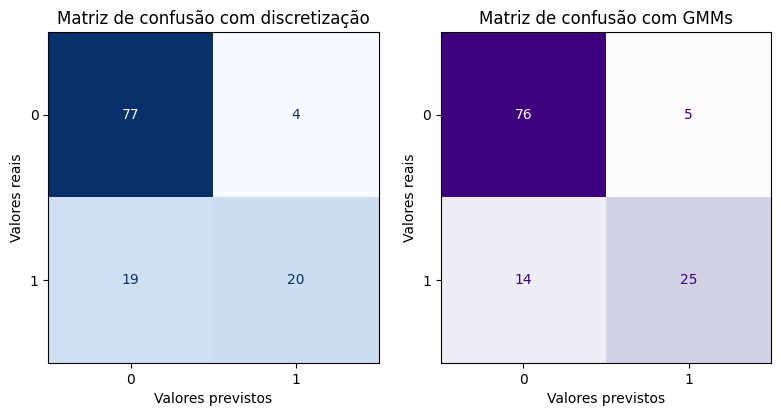

```python
y_pred_discrete = bayesian_model(X_test, features=X_test.columns.tolist())
y_pred_gmm = bayesian_model(X_test, features=X_test.columns.tolist(), continuous='gmm')

acc_disc, acc_gmm = avaliacao(y_test, y_pred_discrete, y_pred_gmm)
```

## **Seleção de variáveis**

```python
def backward_elimination(X_test, y_test):
    best_features_discret = X_test.columns.tolist().copy()
    best_features_gmm = X_test.columns.tolist().copy()

    # Avaliar modelo completo
    y_pred_disc = bayesian_model(X_test, best_features_discret, continuous='discretizacao')
    acc_disc = accuracy_score(y_test, y_pred_disc)

    y_pred_gmm = bayesian_model(X_test, best_features_gmm, continuous='gmm')
    acc_gmm = accuracy_score(y_test, y_pred_gmm)

    improved = True

    while improved:
        improved = False
        for feature in best_features_discret:
            temp_features = best_features_discret.copy()
            temp_features.remove(feature)

            # Avaliar sem a feature removida
            acc_disc_temp = accuracy_score(y_test, bayesian_model(X_test, temp_features, continuous='discretizacao'))

            if acc_disc_temp >= acc_disc:
                acc_disc = acc_disc_temp
                best_features_discret = temp_features
                improved = True
                print(f"[Discretização] Feature removida: {feature} | Accuracy: {acc_disc:.4f}")

        for feature in best_features_gmm:
            temp_features = best_features_gmm.copy()
            temp_features.remove(feature)

            acc_gmm_temp = accuracy_score(y_test, bayesian_model(X_test, temp_features, continuous='gmm'))

            if acc_gmm_temp >= acc_gmm:
                acc_gmm = acc_gmm_temp
                best_features_gmm = temp_features
                improved = True
                print(f"[GMMs] Feature removida: {feature} | Accuracy: {acc_gmm:.4f}")

    print(f"\n==== RESULTADO FINAL ====")
    print(f"> Melhores features (discretização): {best_features_discret} | Accuracy: {acc_disc:.4f}")
    print(f"> Melhores features (GMM): {best_features_gmm} | Accuracy: {acc_gmm:.4f}")

    return best_features_discret, best_features_gmm

best_discrete, best_gmm = backward_elimination(X_test, y_test)
```

```
[Discretização] Feature removida: Gender | Accuracy: 0.8083
[Discretização] Feature removida: N_children | Accuracy: 0.8083
[Discretização] Feature removida: Monthly_Salary | Accuracy: 0.8083
[GMMs] Feature removida: Physical_Status | Accuracy: 0.8583

==== RESULTADO FINAL ====
> Melhores features (discretização): ['Age', 'Marital_status', 'Physical_Status', 'Chronic_disease', 'Recommendation'] | Accuracy: 0.8083
> Melhores features (GMM): ['Gender', 'Age', 'Marital_status', 'N_children', 'Chronic_disease', 'Monthly_Salary', 'Recommendation'] | Accuracy: 0.8583
```

```
==== RESULTADOS COM DISCRETIZAÇÃO ====
              precision    recall  f1-score   support

         0.0       0.82      0.93      0.87        81
         1.0       0.79      0.56      0.66        39

    accuracy                           0.81       120
   macro avg       0.80      0.75      0.76       120
weighted avg       0.81      0.81      0.80       120

Accuracy = 80.83%

==== RESULTADOS COM GMMs ====
              precision    recall  f1-score   support

         0.0       0.86      0.95      0.90        81
         1.0       0.87      0.67      0.75        39

    accuracy                           0.86       120
   macro avg       0.86      0.81      0.83       120
weighted avg       0.86      0.86      0.85       120

Accuracy = 85.83%
```

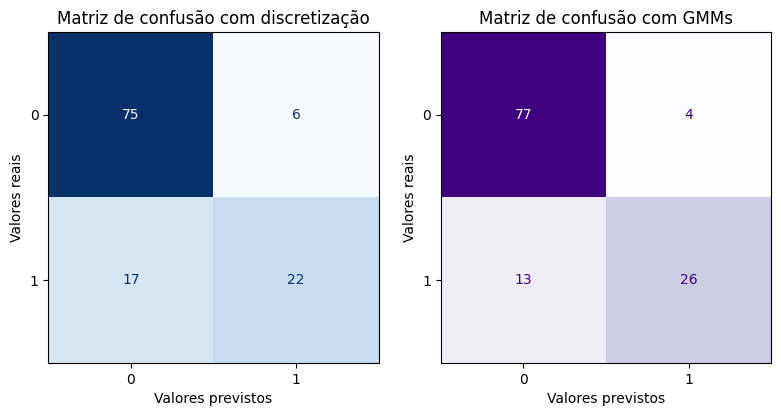

```python
y_pred_discrete = bayesian_model(X_test, features=best_discrete)
y_pred_gmm = bayesian_model(X_test, features=best_gmm, continuous='gmm')

acc_disc, acc_gmm = avaliacao(y_test, y_pred_discrete, y_pred_gmm)
```